# kernel

```python
# This Python 3 environment comes with many helpful analytics libraries installed
# It is defined by the kaggle/python docker image: https://github.com/kaggle/docker-python
# For example, here's several helpful packages to load in

import numpy as np # linear algebra
import pandas as pd # data processing, CSV file I/O (e.g. pd.read_csv)

# Input data files are available in the "../input/" directory.
# For example, running this (by clicking run or pressing Shift+Enter) will list the files in the input directory

import os
print(os.listdir("../input"))

# Any results you write to the current directory are saved as output.
```

```
['911.csv']
```

```python
import matplotlib.pyplot as plt
import seaborn as sns
%matplotlib inline
```

```python
df = pd.read_csv('../input/911.csv')
df.info()
```

```
<class 'pandas.core.frame.DataFrame'>
RangeIndex: 326425 entries, 0 to 326424
Data columns (total 9 columns):
lat          326425 non-null float64
lng          326425 non-null float64
desc         326425 non-null object
zip          286835 non-null float64
title        326425 non-null object
timeStamp    326425 non-null object
twp          326310 non-null object
addr         326425 non-null object
e            326425 non-null int64
dtypes: float64(3), int64(1), object(5)
memory usage: 22.4+ MB
```

```python
df.head()
```

|  | lat | lng | desc | zip | title | timeStamp | twp | addr | e |
| --- | --- | --- | --- | --- | --- | --- | --- | --- | --- |
| 0 | 40.297876 | -75.581294 | REINDEER CT & DEAD END; NEW HANOVER; Station ... | 19525.0 | EMS: BACK PAINS/INJURY | 2015-12-10 17:10:52 | NEW HANOVER | REINDEER CT & DEAD END | 1 |
| 1 | 40.258061 | -75.264680 | BRIAR PATH & WHITEMARSH LN; HATFIELD TOWNSHIP... | 19446.0 | EMS: DIABETIC EMERGENCY | 2015-12-10 17:29:21 | HATFIELD TOWNSHIP | BRIAR PATH & WHITEMARSH LN | 1 |
| 2 | 40.121182 | -75.351975 | HAWS AVE; NORRISTOWN; 2015-12-10 @ 14:39:21-St... | 19401.0 | Fire: GAS-ODOR/LEAK | 2015-12-10 14:39:21 | NORRISTOWN | HAWS AVE | 1 |
| 3 | 40.116153 | -75.343513 | AIRY ST & SWEDE ST; NORRISTOWN; Station 308A;... | 19401.0 | EMS: CARDIAC EMERGENCY | 2015-12-10 16:47:36 | NORRISTOWN | AIRY ST & SWEDE ST | 1 |
| 4 | 40.251492 | -75.603350 | CHERRYWOOD CT & DEAD END; LOWER POTTSGROVE; S... | NaN | EMS: DIZZINESS | 2015-12-10 16:56:52 | LOWER POTTSGROVE | CHERRYWOOD CT & DEAD END | 1 |

```python
df['zip'].value_counts().head(5) # Top five zip codes
```

```
19401.0    22136
19464.0    21588
19403.0    16488
19446.0    15793
19406.0    10800
Name: zip, dtype: int64
```

```python
df['twp'].value_counts().head(5) # Top five townships for 911 calls
```

```
LOWER MERION    28073
ABINGTON        20206
NORRISTOWN      18433
UPPER MERION    17276
CHELTENHAM      15026
Name: twp, dtype: int64
```

Top five townships for 911 emergency calls are: Lower Merion, Abington, Norristown, Upper Merion, Cheltenham.

```python
# Create a separate column which contains reason why call was made : EMS, Traffic or Fire
df['Reason'] = df['title'].apply(lambda x: x.split(':')[0])
df.head()
```

|  | lat | lng | desc | zip | title | timeStamp | twp | addr | e | Reason |
| --- | --- | --- | --- | --- | --- | --- | --- | --- | --- | --- |
| 0 | 40.297876 | -75.581294 | REINDEER CT & DEAD END; NEW HANOVER; Station ... | 19525.0 | EMS: BACK PAINS/INJURY | 2015-12-10 17:10:52 | NEW HANOVER | REINDEER CT & DEAD END | 1 | EMS |
| 1 | 40.258061 | -75.264680 | BRIAR PATH & WHITEMARSH LN; HATFIELD TOWNSHIP... | 19446.0 | EMS: DIABETIC EMERGENCY | 2015-12-10 17:29:21 | HATFIELD TOWNSHIP | BRIAR PATH & WHITEMARSH LN | 1 | EMS |
| 2 | 40.121182 | -75.351975 | HAWS AVE; NORRISTOWN; 2015-12-10 @ 14:39:21-St... | 19401.0 | Fire: GAS-ODOR/LEAK | 2015-12-10 14:39:21 | NORRISTOWN | HAWS AVE | 1 | Fire |
| 3 | 40.116153 | -75.343513 | AIRY ST & SWEDE ST; NORRISTOWN; Station 308A;... | 19401.0 | EMS: CARDIAC EMERGENCY | 2015-12-10 16:47:36 | NORRISTOWN | AIRY ST & SWEDE ST | 1 | EMS |
| 4 | 40.251492 | -75.603350 | CHERRYWOOD CT & DEAD END; LOWER POTTSGROVE; S... | NaN | EMS: DIZZINESS | 2015-12-10 16:56:52 | LOWER POTTSGROVE | CHERRYWOOD CT & DEAD END | 1 | EMS |

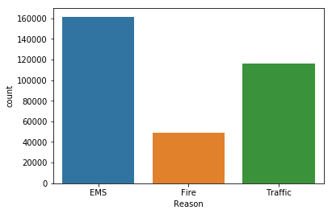

```python
sns.countplot(df['Reason'])
```

Highest number of calls are for emergency and medical services(EMS), followed by traffic, followed by fire

```python
emstype = df[df['Reason'] == 'EMS']['title']
emstype.value_counts().head(10)
```

```
EMS: RESPIRATORY EMERGENCY        16602
EMS: FALL VICTIM                  16438
EMS: CARDIAC EMERGENCY            16100
EMS: VEHICLE ACCIDENT             12976
EMS: SUBJECT IN PAIN               9149
EMS: HEAD INJURY                   8491
EMS: UNKNOWN MEDICAL EMERGENCY     5670
EMS: SYNCOPAL EPISODE              5554
EMS: SEIZURES                      5371
EMS: GENERAL WEAKNESS              5339
Name: title, dtype: int64
```

So top five reasons for EMS calls are: Respiratory emergency, fall victim, cardiac emergency, vehicle accident and subject in pain.

```python
firetype = df[df['Reason'] == 'Fire']['title']
firetype.value_counts().head(10)
```

```
Fire: FIRE ALARM                  18436
Fire: VEHICLE ACCIDENT             5541
Fire: FIRE INVESTIGATION           4636
Fire: GAS-ODOR/LEAK                3403
Fire: BUILDING FIRE                2452
Fire: ELECTRICAL FIRE OUTSIDE      2331
Fire: FIRE SPECIAL SERVICE         1938
Fire: CARBON MONOXIDE DETECTOR     1863
Fire: VEHICLE FIRE                 1657
Fire: WOODS/FIELD FIRE             1306
Name: title, dtype: int64
```

```python
traffictype = df[df['Reason'] == 'Traffic']['title']
traffictype.value_counts().head(10)
```

```
Traffic: VEHICLE ACCIDENT -             76179
Traffic: DISABLED VEHICLE -             23957
Traffic: ROAD OBSTRUCTION -             10668
Traffic: HAZARDOUS ROAD CONDITIONS -     3222
Traffic: VEHICLE FIRE -                  1739
Traffic: VEHICLE LEAKING FUEL -           183
Traffic: DEBRIS/FLUIDS ON HIGHWAY -       117
Name: title, dtype: int64
```

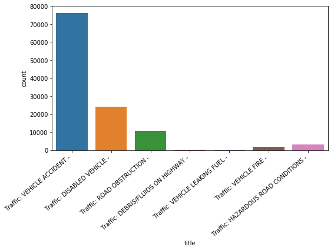

```python
plt.figure(figsize=(8,6))
ax = sns.countplot( traffictype)
ax.set_xticklabels(ax.get_xticklabels(), rotation=40, ha="right")
#plt.set_xlabel('Fire calls type')
plt.tight_layout()
plt.show()
```

In all the three reasons for 911 calls, we see "Vehicle accident' in the top five ( a cause of grave concern.....)

Next we try to extract information from time stamp column

```python
#timeStamp column contains a lot of information which can be extracted.
type(df['timeStamp'][0])
```

```
str
```

```python
#timeStamp entries are a string. We have to convert it to datetime format

df['timeStamp']= pd.to_datetime(df['timeStamp'])
type(df['timeStamp'][0])
```

```
pandas._libs.tslibs.timestamps.Timestamp
```

```python
#Create three new columns which contain information of day, date, hour
df['Date']=df['timeStamp'].apply(lambda x: x.date())
df['Day'] =df['timeStamp'].apply(lambda x:x.dayofweek)
df['Hour'] =df['timeStamp'].apply(lambda x:x.hour)
```

```python
df.head()
```

|  | lat | lng | desc | zip | title | timeStamp | twp | addr | e | Reason | Date | Day | Hour |
| --- | --- | --- | --- | --- | --- | --- | --- | --- | --- | --- | --- | --- | --- |
| 0 | 40.297876 | -75.581294 | REINDEER CT & DEAD END; NEW HANOVER; Station ... | 19525.0 | EMS: BACK PAINS/INJURY | 2015-12-10 17:10:52 | NEW HANOVER | REINDEER CT & DEAD END | 1 | EMS | 2015-12-10 | 3 | 17 |
| 1 | 40.258061 | -75.264680 | BRIAR PATH & WHITEMARSH LN; HATFIELD TOWNSHIP... | 19446.0 | EMS: DIABETIC EMERGENCY | 2015-12-10 17:29:21 | HATFIELD TOWNSHIP | BRIAR PATH & WHITEMARSH LN | 1 | EMS | 2015-12-10 | 3 | 17 |
| 2 | 40.121182 | -75.351975 | HAWS AVE; NORRISTOWN; 2015-12-10 @ 14:39:21-St... | 19401.0 | Fire: GAS-ODOR/LEAK | 2015-12-10 14:39:21 | NORRISTOWN | HAWS AVE | 1 | Fire | 2015-12-10 | 3 | 14 |
| 3 | 40.116153 | -75.343513 | AIRY ST & SWEDE ST; NORRISTOWN; Station 308A;... | 19401.0 | EMS: CARDIAC EMERGENCY | 2015-12-10 16:47:36 | NORRISTOWN | AIRY ST & SWEDE ST | 1 | EMS | 2015-12-10 | 3 | 16 |
| 4 | 40.251492 | -75.603350 | CHERRYWOOD CT & DEAD END; LOWER POTTSGROVE; S... | NaN | EMS: DIZZINESS | 2015-12-10 16:56:52 | LOWER POTTSGROVE | CHERRYWOOD CT & DEAD END | 1 | EMS | 2015-12-10 | 3 | 16 |

```python
# Day is in number, we want to map it to Monday to Sunaday so we use .map() function
getday={0:'Mon',1:'Tue',2:'Wed',3:'Thu',4:'Fri',5:'Sat',6:'Sun'}
df['Day']=df['Day'].map(getday)
```

```python
df.head()
```

|  | lat | lng | desc | zip | title | timeStamp | twp | addr | e | Reason | Date | Day | Hour |
| --- | --- | --- | --- | --- | --- | --- | --- | --- | --- | --- | --- | --- | --- |
| 0 | 40.297876 | -75.581294 | REINDEER CT & DEAD END; NEW HANOVER; Station ... | 19525.0 | EMS: BACK PAINS/INJURY | 2015-12-10 17:10:52 | NEW HANOVER | REINDEER CT & DEAD END | 1 | EMS | 2015-12-10 | Thu | 17 |
| 1 | 40.258061 | -75.264680 | BRIAR PATH & WHITEMARSH LN; HATFIELD TOWNSHIP... | 19446.0 | EMS: DIABETIC EMERGENCY | 2015-12-10 17:29:21 | HATFIELD TOWNSHIP | BRIAR PATH & WHITEMARSH LN | 1 | EMS | 2015-12-10 | Thu | 17 |
| 2 | 40.121182 | -75.351975 | HAWS AVE; NORRISTOWN; 2015-12-10 @ 14:39:21-St... | 19401.0 | Fire: GAS-ODOR/LEAK | 2015-12-10 14:39:21 | NORRISTOWN | HAWS AVE | 1 | Fire | 2015-12-10 | Thu | 14 |
| 3 | 40.116153 | -75.343513 | AIRY ST & SWEDE ST; NORRISTOWN; Station 308A;... | 19401.0 | EMS: CARDIAC EMERGENCY | 2015-12-10 16:47:36 | NORRISTOWN | AIRY ST & SWEDE ST | 1 | EMS | 2015-12-10 | Thu | 16 |
| 4 | 40.251492 | -75.603350 | CHERRYWOOD CT & DEAD END; LOWER POTTSGROVE; S... | NaN | EMS: DIZZINESS | 2015-12-10 16:56:52 | LOWER POTTSGROVE | CHERRYWOOD CT & DEAD END | 1 | EMS | 2015-12-10 | Thu | 16 |

Now with the extra information in these 3 columns we can extract lot of extra infomation, like which part of the day frequency of calls is more, etc

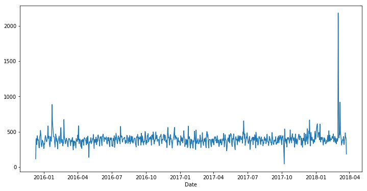

```python
plt.figure(figsize=(12,6))
df.groupby('Date')
df2=df.groupby('Date').count()
df2['twp'].plot.line()
```

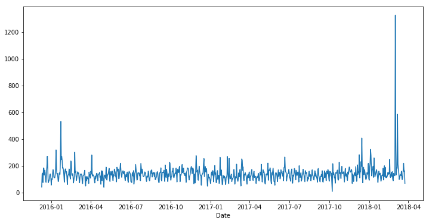

```python
plt.figure(figsize=(12,6))
df3 = df[df['Reason'] == 'Traffic'].groupby('Date').count()
df3['twp'].plot.line()
```

On 2nd, 3rd and 7th of March 2018, number of 911 calls for traffic are very high

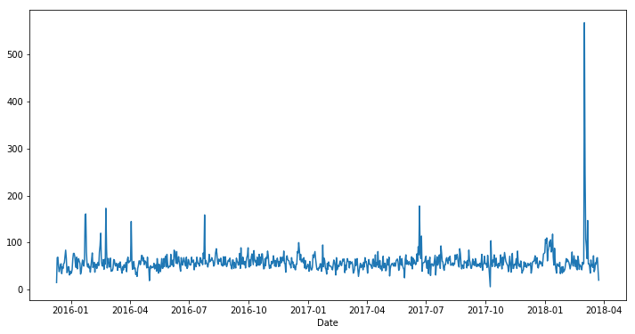

```python
plt.figure(figsize=(12,6))
df3 = df[df['Reason'] == 'Fire'].groupby('Date').count()
df3['twp'].plot.line()
```

Number of fire calls were very high on 2nd March 2018

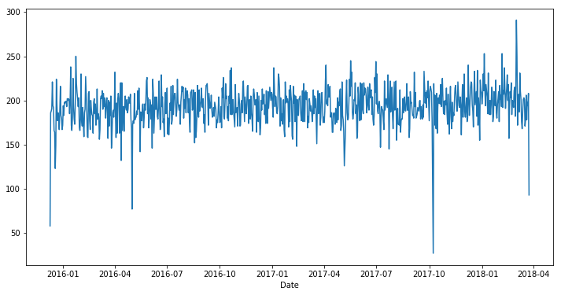

```python
plt.figure(figsize=(12,6))
df3 = df[df['Reason'] == 'EMS'].groupby('Date').count()
df3['twp'].plot.line()
```

```python
#dayhour = df.groupby(by=['Reason','Day', 'Hour']).count()['lat'].unstack('Hour')
```

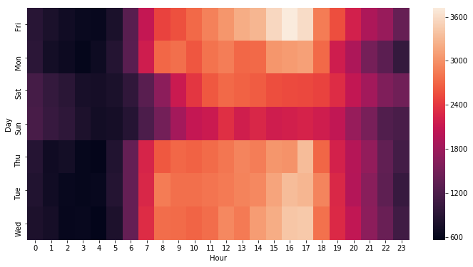

```python
dayHour = df.groupby(by=['Day','Hour']).count()['Reason'].unstack()
dayHour.head()
plt.figure(figsize=(12,6))
sns.heatmap(dayHour)
```

Majority of the 911 calls are between 7am and 7pm. But there are a substantial number of calls at night and early morning hours as well

Future Plan: This analysis may be furthur carried out for each of the causes to derive more insights.

Kindly point out mistakes if any